# Logistic Regression for Loansharks (2017 Pennsylvania)

# Model with census data integrated.

```r
# https://www2.census.gov/programs-surveys/popest/datasets/2010-2018/counties/asrh/
census_pa_file_path <- paste(census_data_dir, sep = "", "/cc-est2018-alldata-42.csv")

merged_hmda_data_df_for_model <- merge_hmda_df_with_census(census_pa_file_path, hmda_data_df_for_model)

split_dfs <- train_test_split(merged_hmda_data_df_for_model$loan_granted, merged_hmda_data_df_for_model)

merged_train <- split_dfs[[1]]
merged_test <- split_dfs[[2]]

merged_2017_model <- build_glm_model("loan_granted~applicant_race_and_ethnicity+owner_occupancy+preapproval+property_type+log_loan_amount_000s+tract_to_msamd_income+co_applicant_present+agency_code+BLACK_PERCENT+ASIAN_PERCENT+HISPANIC_PERCENT+county_code+respondent_id+applicant_sex+loan_purpose+loan_to_income_ratio", merged_train)
```

```
glm.fit: fitted probabilities numerically 0 or 1 occurred
```

```r
model5_fitted.probs <- predict(merged_2017_model, merged_test, type = "response")

writeLines("")
```

```r
writeLines("Merged model performance")
```

```
Merged model performance
```

```
[1] "no"  "yes"
[1] "Accuracy 0.766961651917404"
Confusion Matrix and Statistics

          Reference
Prediction    no   yes
       no   6220  4775
       yes  7154 33040

               Accuracy : 0.767
                 95% CI : (0.7633, 0.7706)
    No Information Rate : 0.7387
    P-Value [Acc > NIR] : < 0.00000000000000022

                  Kappa : 0.3595

 Mcnemar's Test P-Value : < 0.00000000000000022

            Sensitivity : 0.8737
            Specificity : 0.4651
         Pos Pred Value : 0.8220
         Neg Pred Value : 0.5657
             Prevalence : 0.7387
         Detection Rate : 0.6455
   Detection Prevalence : 0.7852
      Balanced Accuracy : 0.6694

       'Positive' Class : yes

Confusion Matrix and Statistics

          Reference
Prediction    no   yes
       no   6220  4775
       yes  7154 33040

               Accuracy : 0.767
                 95% CI : (0.7633, 0.7706)
    No Information Rate : 0.7387
    P-Value [Acc > NIR] : < 0.00000000000000022
```

[output cut: 11 more lines]

```
   Detection Prevalence : 0.7852
      Balanced Accuracy : 0.6694

       'Positive' Class : yes

[1] "Precision not found"
[1] "Prevalence"
[1] "Precision and Recall"
[1] 0.8220132
[1] 0.8737274
[[1]]
[1] 0.8220132

[[2]]
[1] 0.8737274
```

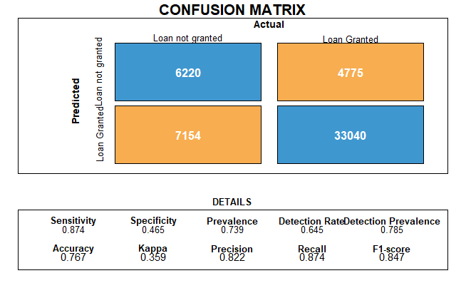

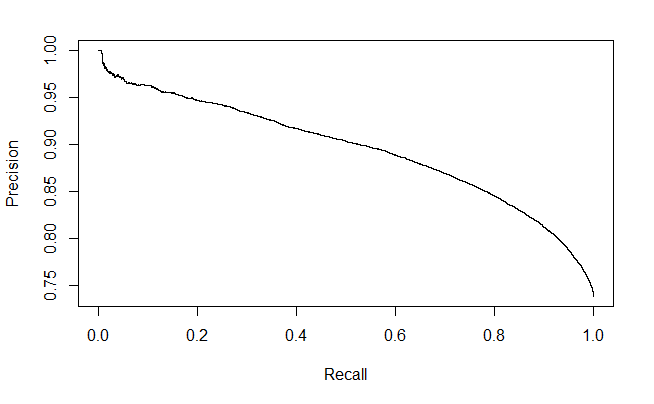

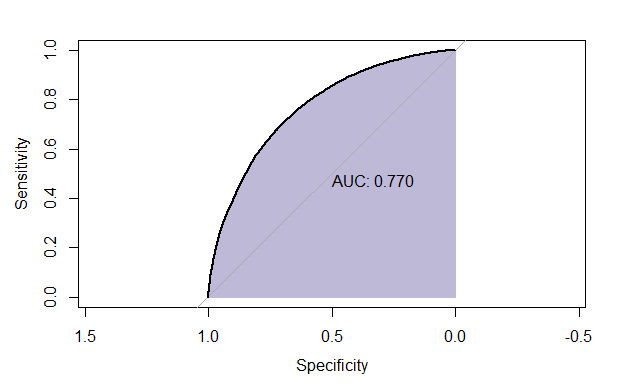

```r
print_model_performance(model5_fitted.probs, merged_test, positive = "yes", negative = "no", threshold = 0.6)
```

# Loan to value ratio is an important metric which banks use to decide

# whether a loan should be granted or not. For e.g. the higher the loan

# to value ratio the riskier it is for the bank.

# https://en.wikipedia.org/wiki/Loan-to-value_ratio

# Banks are not required to report this metric in the HMDA reporting

# law. We use the median of the home values in that county based on

# data available from zillow https://www.zillow.com/research/data/

```r
period_list <- c("2017-01", "2017-02", "2017-03", "2017-04",
                 "2017-05", "2017-06", "2017-07", "2017-08",
                 "2017-09", "2017-10", "2017-11", "2017-12")

merged_hmda_with_loan_to_value_ratio <- augment_hmda_data_with_estimated_loan_to_value_ratio_from_zillow(paste(data_dir, "/zillow/counties_home_value_per_year.csv", sep = ""), hmda_data_df_for_model, "PA", period_list)
```

```
 [1] "2017-01"    "2017-02"    "2017-03"    "2017-04"    "2017-05"
 [6] "2017-06"    "2017-07"    "2017-08"    "2017-09"    "2017-10"
[11] "2017-11"    "2017-12"    "RegionName"
```

```r
head(merged_hmda_with_loan_to_value_ratio)
```

|  | county_name | applicant_race_and_ethnicity | applicant_income_000s | co_applicant_race_and_ethnicity | co_applicant_sex | hoepa_status | lien_status | msamd | owner_occupancy | preapproval | purchaser_type | property_type | loan_amount_000s | applicant_sex | hud_median_family_income | tract_to_msamd_income | loan_to_income_ratio | agency_code | minority_population | loan_purpose | rate_spread | population | number_of_owner_occupied_units | loan_granted | log_loan_amount_000s | log_applicant_income_000s | credit_score | co_applicant_present | respondent_id | … |
| --- | --- | --- | --- | --- | --- | --- | --- | --- | --- | --- | --- | --- | --- | --- | --- | --- | --- | --- | --- | --- | --- | --- | --- | --- | --- | --- | --- | --- | --- | --- |
| 1 | Adams County | White | 81 | White | 2 | 2 | 1 | 23900 | 1 | 3 | 1 | 1 | 132 | 1 | 73900 | 95.40 | 1.629630 | 7 | 16.02 | 3 | 2.28 | 3401 | 209 | yes | 4.882802 | 4.394449 | 734 | 1 | 7197000003 | … |
| 2 | Adams County | White | 83 | White | 2 | 2 | 1 | 23900 | 1 | 3 | 1 | 1 | 114 | 1 | 73900 | 80.18 | 1.373494 | 9 | 8.38 | 3 | 1.51 | 4929 | 1232 | yes | 4.736198 | 4.418841 | 734 | 1 | other | … |
| 3 | Adams County | White | 83 | No co-applicant | 5 | 2 | 1 | 23900 | 2 | 3 | 6 | 1 | 167 | 2 | 73900 | 80.18 | 2.012048 | 7 | 8.38 | 1 | 1.75 | 4929 | 1232 | yes | 5.117994 | 4.418841 | 734 | 0 | 01-0464609 | … |
| 4 | Adams County | White | 76 | No co-applicant | 5 | 2 | 1 | 23900 | 1 | 3 | 7 | 1 | 128 | 1 | 73900 | 91.48 | 1.684211 | 3 | 15.12 | 3 | 1.67 | 7826 | 1907 | yes | 4.852030 | 4.330733 | 734 | 0 | other | … |
| 5 | Adams County | White | 110 | White | 2 | 2 | 1 | 23900 | 2 | 3 | 0 | 1 | 550 | 1 | 73900 | 96.22 | 5.000000 | 3 | 11.30 | 3 | 1.53 | 6574 | 2071 | yes | 6.309918 | 4.700480 | 734 | 1 | other | … |
| 6 | Adams County | White | 85 | White | 2 | 2 | 1 | 23900 | 1 | 3 | 0 | 1 | 341 | 1 | 73900 | 96.95 | 4.011765 | 9 | 5.39 | 3 | 1.69 | 5809 | 1897 | yes | 5.831882 | 4.442651 | 734 | 1 | 0000617677 | … |

```r
NA
```

# Train test split on the hmda dataset merged with estimated loan to value

# ratio

```r
split_dfs <- train_test_split(merged_hmda_with_loan_to_value_ratio$loan_granted, merged_hmda_with_loan_to_value_ratio)
new_train <- split_dfs[[1]]
new_test <- split_dfs[[2]]
```

## Model with estimated loan to value ratio.

```r
model_2017_with_loan_to_value_ratio <-
build_glm_model("loan_granted~applicant_race_and_ethnicity+owner_occupancy+preapproval+log_loan_amount_000s+applicant_sex+county_code+tract_to_msamd_income+co_applicant_present+agency_code+minority_population+loan_to_income_ratio+loan_purpose+rate_spread+property_type+loan_to_value_ratio+respondent_id", new_train)
```

```
glm.fit: fitted probabilities numerically 0 or 1 occurred
```

```
Model summary


Call:
glm(formula = as.formula(model_formula), family = binomial(link = "logit"),
    data = train_df, control = glm.control(maxit = iter))

Deviance Residuals:
    Min       1Q   Median       3Q      Max
-3.2079  -0.6829   0.4936   0.7503   8.4904

Coefficients:
                                                                                                                 Estimate
(Intercept)                                                                                                    1.25279292
applicant_race_and_ethnicityAsian                                                                              0.15184169
applicant_race_and_ethnicityBlack or African American                                                         -0.31881266
applicant_race_and_ethnicityHispanic or Latino                                                                -0.20221796
applicant_race_and_ethnicityInformation not provided by applicant in mail, Internet, or telephone application  0.08720738
applicant_race_and_ethnicityNative Hawaiian or Other Pacific Islander                                         -0.08584187
applicant_race_and_ethnicityNot applicable                                                                     0.85271719
applicant_race_and_ethnicityWhite                                                                              0.33566872
owner_occupancy2                                                                                              -0.16215500
owner_occupancy3                                                                                              -0.08538337
preapproval2                                                                                                  -0.80071153
preapproval3                                                                                                  -0.84556611
log_loan_amount_000s                                                                                           0.18588694
applicant_sex2                                                                                                -0.01832673
applicant_sex3                                                                                                -0.21084478
applicant_sex4                                                                                                 0.40924654
county_code14                                                                                                  0.08456122
county_code15                                                                                                  0.03934527
county_code2                                                                                                   0.02255714
county_code21                                                                                                 -0.04169282
county_code22                                                                                                 -0.09193884
county_code23                                                                                                 -0.35776377
county_code25                                                                                                 -0.32161695
county_code26                                                                                                 -0.25107570
county_code28                                                                                                 -0.16733426
county_code35                                                                                                 -0.37458945
county_code36                                                                                                 -0.01995343
```

[output cut: 504 more lines]

```
respondent_id7734800004                                                                                       ***
respondent_id7810600004                                                                                       ***
respondent_idother                                                                                            ***
---
Signif. codes:  0 ‘***’ 0.001 ‘**’ 0.01 ‘*’ 0.05 ‘.’ 0.1 ‘ ’ 1

(Dispersion parameter for binomial family taken to be 1)

    Null deviance: 235218  on 204757  degrees of freedom
Residual deviance: 197170  on 204652  degrees of freedom
AIC: 197382

Number of Fisher Scoring iterations: 7

Anova for model
```

[output not shown]

```
Analysis of Deviance Table

Model: binomial, link: logit

Response: loan_granted

Terms added sequentially (first to last)

                             Df Deviance Resid. Df Resid. Dev
NULL                                        204757     235218
applicant_race_and_ethnicity  7   5985.2    204750     229233
owner_occupancy               2     12.0    204748     229221
preapproval                   2   4638.3    204746     224582
log_loan_amount_000s          1   5248.1    204745     219334
applicant_sex                 3    136.7    204742     219198
county_code                  25    547.7    204717     218650
tract_to_msamd_income         1    335.1    204716     218315
co_applicant_present          1    866.5    204715     217448
agency_code                   5   3673.3    204710     213775
minority_population           1     43.6    204709     213731
loan_to_income_ratio          1   1272.6    204708     212459
loan_purpose                  2   5853.9    204706     206605
rate_spread                   1   1864.3    204705     204741
property_type                 2   2175.2    204703     202565
loan_to_value_ratio           1      0.0    204702     202565
respondent_id                50   5395.1    204652     197170
                                          Pr(>Chi)
NULL
applicant_race_and_ethnicity < 0.00000000000000022 ***
owner_occupancy                           0.002499 **
preapproval                  < 0.00000000000000022 ***
log_loan_amount_000s         < 0.00000000000000022 ***
applicant_sex                < 0.00000000000000022 ***
county_code                  < 0.00000000000000022 ***
tract_to_msamd_income        < 0.00000000000000022 ***
co_applicant_present         < 0.00000000000000022 ***
agency_code                  < 0.00000000000000022 ***
minority_population                0.0000000000394 ***
loan_to_income_ratio         < 0.00000000000000022 ***
loan_purpose                 < 0.00000000000000022 ***
rate_spread                  < 0.00000000000000022 ***
property_type                < 0.00000000000000022 ***
loan_to_value_ratio                       0.878908
respondent_id                < 0.00000000000000022 ***
---
Signif. codes:  0 ‘***’ 0.001 ‘**’ 0.01 ‘*’ 0.05 ‘.’ 0.1 ‘ ’ 1
```

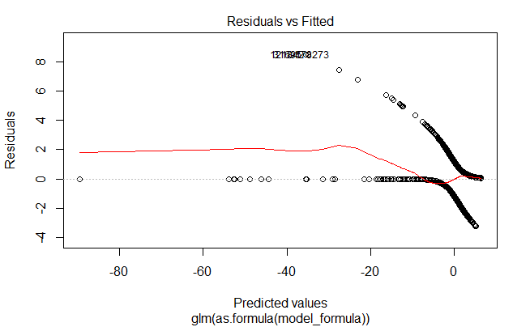

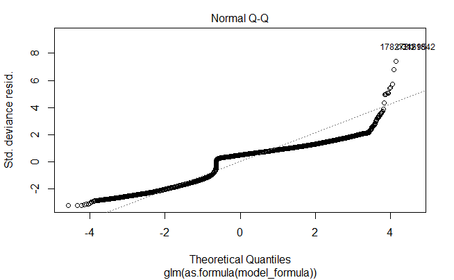

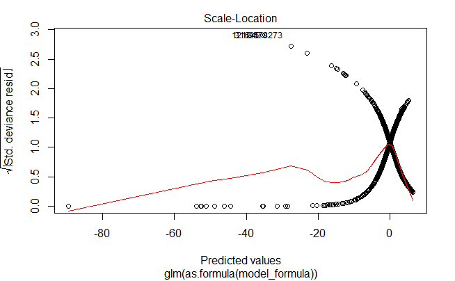

```
optimal cut threshold is
                 [,1]
sensitivity 0.7079750
specificity 0.6948614
cutoff      0.7289874
```

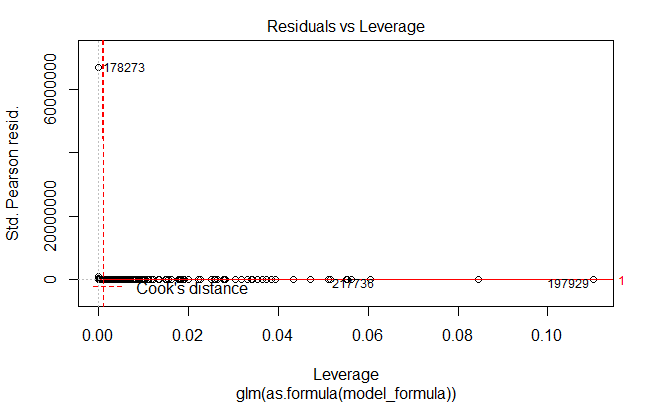

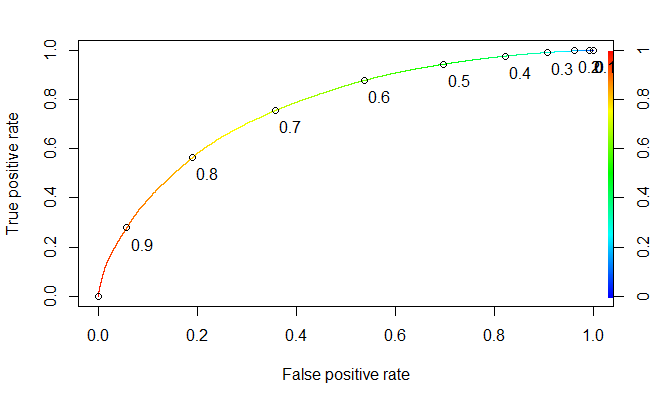

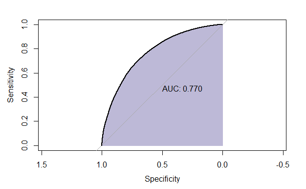

```r
model_summary_and_plot(model_2017_with_loan_to_value_ratio, train = new_train)
```

```r
mcfadden_r_square(model_2017_with_loan_to_value_ratio, null_model)
```

```
Mcfadden Rsquare value
'log Lik.' 0.1633608 (df=106)
```

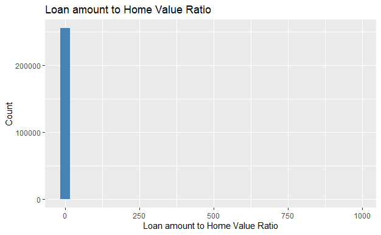

```r
ggplot(data = merged_hmda_with_loan_to_value_ratio, aes(x=loan_to_value_ratio)) +geom_histogram(fill = "steelblue") + labs(title = "Loan amount to Home Value Ratio" , x = "Loan amount to Home Value Ratio",y="Count")
```

```r
model6_fitted.probs <- predict(model_2017_with_loan_to_value_ratio, new_test, type = "response")

writeLines("")
```

```r
writeLines("Model with estimated loan to value ratio performance")
```

```
Model with estimated loan to value ratio performance
```

```
[1] "no"  "yes"
[1] "Accuracy 0.768563558577038"
Confusion Matrix and Statistics

          Reference
Prediction    no   yes
       no   6170  4643
       yes  7204 33172

               Accuracy : 0.7686
                 95% CI : (0.7649, 0.7722)
    No Information Rate : 0.7387
    P-Value [Acc > NIR] : < 0.00000000000000022

                  Kappa : 0.3609

 Mcnemar's Test P-Value : < 0.00000000000000022

            Sensitivity : 0.8772
            Specificity : 0.4613
         Pos Pred Value : 0.8216
         Neg Pred Value : 0.5706
             Prevalence : 0.7387
         Detection Rate : 0.6480
   Detection Prevalence : 0.7888
      Balanced Accuracy : 0.6693

       'Positive' Class : yes

Confusion Matrix and Statistics

          Reference
Prediction    no   yes
       no   6170  4643
       yes  7204 33172

               Accuracy : 0.7686
                 95% CI : (0.7649, 0.7722)
    No Information Rate : 0.7387
    P-Value [Acc > NIR] : < 0.00000000000000022
```

[output cut: 11 more lines]

```
   Detection Prevalence : 0.7888
      Balanced Accuracy : 0.6693

       'Positive' Class : yes

[1] "Precision not found"
[1] "Prevalence"
[1] "Precision and Recall"
[1] 0.8215772
[1] 0.877218
[[1]]
[1] 0.8215772

[[2]]
[1] 0.877218
```

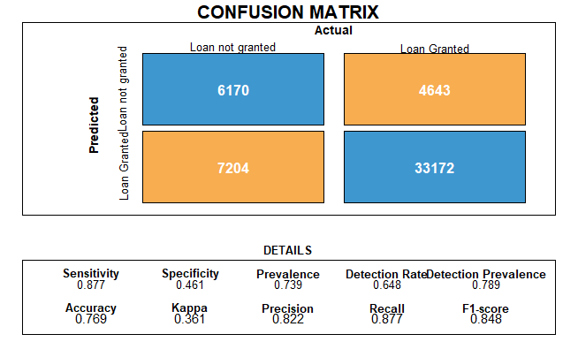

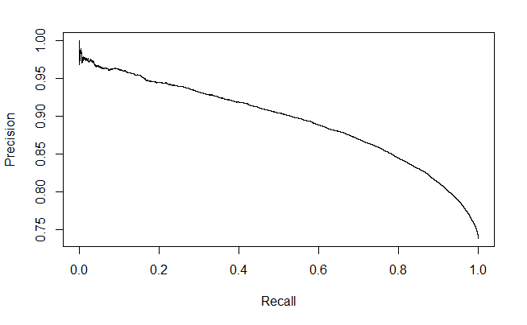

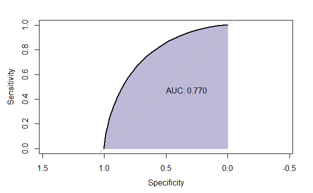

```r
print_model_performance(model6_fitted.probs, new_test, positive = "yes", negative = "no", threshold = 0.6)
```

# Save the models

```r
dir.create(model_path, showWarnings = FALSE)
save(model_2017_income_loan_amount, file = paste(model_path, "/model_income_loan_amount.rdata", sep=""))
save(model_2017_log_income_loan_amount, file = paste(model_path, "/model_log_income_loan_amount.rdata", sep=""))
save(model_2017_ratio_of_loan_to_income_with_log_of_income_and_amount, file = paste(model_path, "/model_loan_income_ratio_with_log_of_income_and_amount.rdata", sep=""))
save(model_2017_cross_val_loan_income_ratio, file = paste(model_path, "/cross_val_model.rdata", sep=""))
save(merged_2017_model, file = paste(model_path, "/merged_model.rdata", sep=""))

save(model_2017_with_loan_to_value_ratio, file = paste(model_path, "/merged_model_with_loan_to_value.rdata", sep=""))
```

# Save the train and test data for future reference.

```r
dir.create(model_data_path, showWarnings = FALSE)
save(train, file = paste(model_data_path, "/train.rdata", sep = ""))
save(test, file = paste(model_data_path, "/test.rdata", sep = ""))

dir.create(model_data_path, showWarnings = FALSE)
save(merged_train, file = paste(model_data_path, "/merged_train.rdata", sep = ""))
save(merged_test, file = paste(model_data_path, "/merged_test.rdata", sep = ""))

dir.create(model_data_path, showWarnings = FALSE)
save(new_train, file = paste(model_data_path, "/train_with_loan_to_value.rdata", sep = ""))
save(new_test, file = paste(model_data_path, "/test_with_loan_to_value.rdata", sep = ""))
```